# R Notebook

```r
knitr::opts_chunk$set(echo = TRUE)
```

### Dependency

```r
##library(tidyverse)
library(readxl)
```

```r
#load necessary libraries
library(ggplot2)
library(ggpubr)
```

# Problem 2.152

## A) Solution:

### Read xls file

```r
file_name = "ex02-152meis.xls"
data = read_xls(file_name)
```

### Preview tibble

```r
data
```

| Country | Sales | Production | DwellPermit |
| --- | --- | --- | --- |
| Australia | 137 | 109 | 116 |
| Belgium | 105 | 112 | 125 |
| Canada | 122 | 101 | 224 |
| Czech Republic | 134 | 162 | 178 |
| Denmark | 126 | 109 | 121 |
| Finland | 136 | 125 | 105 |
| France | 121 | 104 | 145 |
| Germany | 100 | 119 | 54 |
| Greece | 136 | 102 | 117 |
| Hungary | 140 | 155 | 109 |

[output cut: 11 more lines]

```r
summary(data)
```

```
   Country              Sales         Production     DwellPermit
 Length:21          Min.   : 99.0   Min.   : 94.0   Min.   : 53.0
 Class :character   1st Qu.:112.0   1st Qu.:108.0   1st Qu.:109.0
 Mode  :character   Median :126.0   Median :112.0   Median :125.0
                    Mean   :126.1   Mean   :120.4   Mean   :128.8
                    3rd Qu.:137.0   3rd Qu.:125.0   3rd Qu.:158.0
                    Max.   :161.0   Max.   :162.0   Max.   :224.0
```

```r
fit<- lm(data$Sales~ data$DwellPermit)
summary(fit)
```

```
Call:
lm(formula = data$Sales ~ data$DwellPermit)

Residuals:
    Min      1Q  Median      3Q     Max
-23.036 -16.122   1.556  11.397  32.859

Coefficients:
                 Estimate Std. Error t value Pr(>|t|)
(Intercept)      109.8204    11.5582   9.501 1.19e-08 ***
data$DwellPermit   0.1263     0.0857   1.474    0.157
---
Signif. codes:  0 ‘***’ 0.001 ‘**’ 0.01 ‘*’ 0.05 ‘.’ 0.1 ‘ ’ 1

Residual standard error: 15.7 on 19 degrees of freedom
Multiple R-squared:  0.1027,    Adjusted R-squared:  0.05543
F-statistic: 2.174 on 1 and 19 DF,  p-value: 0.1568
```

```r
b = unname(fit$coefficients[1])
a = unname(fit$coefficients[2])
```

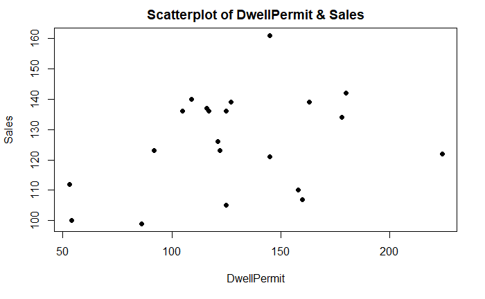

```r
# Scatterplot of DwellPermit & Sales
plot(data$DwellPermit, data$Sales, main="Scatterplot of DwellPermit & Sales",
   xlab="DwellPermit", ylab="Sales", pch=19)
```

*There seems be a week positive association and one outlier near x=145 (Luxembourg)*

## B) Solution:

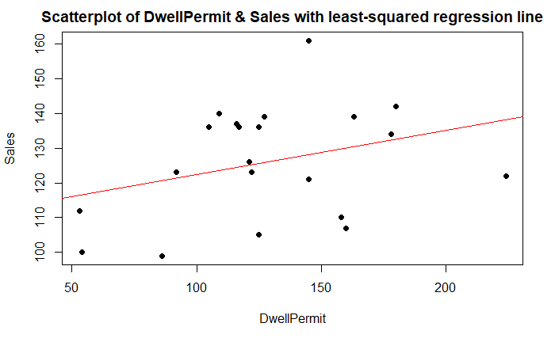

```r
# Scatterplot of DwellPermit & Sales

plot(data$DwellPermit, data$Sales, main="Scatterplot of DwellPermit & Sales with least-squared regression line",
   xlab="DwellPermit", ylab="Sales", pch=19)
# Add fit lines
abline(lm(Sales~DwellPermit, data = data), col="red") # regression line (y~x)
```

### Using ggplot2

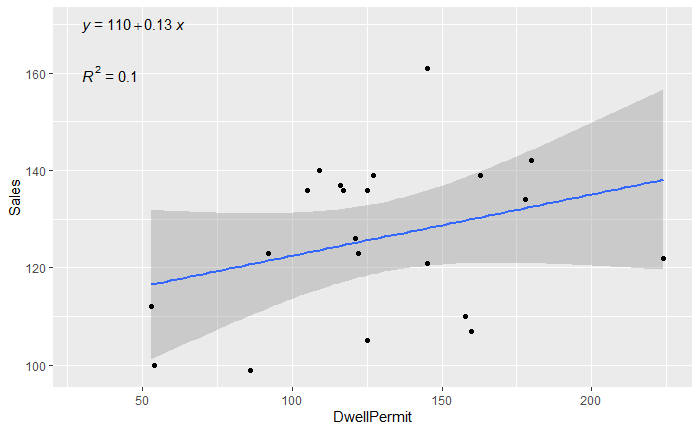

```r
#create plot with regression line, regression equation, and R-squared
ggplot(data=data, aes(x=DwellPermit, y=Sales)) +
        geom_smooth(method="lm") +
        geom_point() +
        stat_regline_equation(label.x=30, label.y=170) +
        stat_cor(aes(label=..rr.label..), label.x=30, label.y=160)
```

## C) Solution:

```r
x = 160
sales = a*x + b
print(paste("Predicted value of sales for a country that has an index of 160 for dwelling permits is", sales))
```

```
[1] "Predicted value of sales for a country that has an index of 160 for dwelling permits is 130.036089058185"
```

## D) Solution:

```r
id = which(data$Country == "Netherlands" & data$DwellPermit==160)
```

```r
#List of residual for Netherlands (15th on the list)
print(paste("Residual for Netherlands is",resid(fit)[id]))
```

```
[1] "Residual for Netherlands is -23.0360890581847"
```

## E) Solution:

```r
data$xbar_diff = data$DwellPermit- mean(data$DwellPermit)
data$ybar_diff = data$Sales- mean(data$Sales)
data$xbar_diffs = (data$DwellPermit- mean(data$DwellPermit))^2
data$ybar_diffs = (data$Sales- mean(data$Sales))^2
data$xy = data$xbar_diff * data$ybar_diff
data
```

| Country | Sales | Production | DwellPermit | xbar_diff | ybar_diff | xbar_diffs | ybar_diffs | xy |
| --- | --- | --- | --- | --- | --- | --- | --- | --- |
| Australia | 137 | 109 | 116 | -12.809524 | 10.9047619 | 164.083900 | 1.189138e+02 | -139.6848073 |
| Belgium | 105 | 112 | 125 | -3.809524 | -21.0952381 | 14.512472 | 4.450091e+02 | 80.3628118 |
| Canada | 122 | 101 | 224 | 95.190476 | -4.0952381 | 9061.226757 | 1.677098e+01 | -389.8276644 |
| Czech Republic | 134 | 162 | 178 | 49.190476 | 7.9047619 | 2419.702948 | 6.248526e+01 | 388.8390023 |
| Denmark | 126 | 109 | 121 | -7.809524 | -0.0952381 | 60.988662 | 9.070295e-03 | 0.7437642 |
| Finland | 136 | 125 | 105 | -23.809524 | 9.9047619 | 566.893424 | 9.810431e+01 | -235.8276644 |
| France | 121 | 104 | 145 | 16.190476 | -5.0952381 | 262.131519 | 2.596145e+01 | -82.4943311 |
| Germany | 100 | 119 | 54 | -74.809524 | -26.0952381 | 5596.464853 | 6.809615e+02 | 1952.1723356 |
| Greece | 136 | 102 | 117 | -11.809524 | 9.9047619 | 139.464853 | 9.810431e+01 | -116.9705215 |
| Hungary | 140 | 155 | 109 | -19.809524 | 13.9047619 | 392.417234 | 1.933424e+02 | -275.4467120 |

[output cut: 11 more lines]

```r
r = (sum(data$xy))/sqrt(sum(data$ybar_diffs) * sum(data$xbar_diffs))
r^2
```

```
[1] 0.1026555
```

```r
cor(data$DwellPermit, data$Sales)
```

```
[1] 0.320399
```

### Alternate solution:

```r
rsq <-  cor(data$DwellPermit, data$Sales) ^ 2
rsq
```

```
[1] 0.1026555
```

*So 10.27% of the variance of sales can be explained by dwelling permits*

# Problem 2.153

## A) Solution:

### Read xls file

```r
file_name = "ex02-152meis.xls"
data = read_xls(file_name)
```

### Preview tibble

```r
data
```

| Country | Sales | Production | DwellPermit |
| --- | --- | --- | --- |
| Australia | 137 | 109 | 116 |
| Belgium | 105 | 112 | 125 |
| Canada | 122 | 101 | 224 |
| Czech Republic | 134 | 162 | 178 |
| Denmark | 126 | 109 | 121 |
| Finland | 136 | 125 | 105 |
| France | 121 | 104 | 145 |
| Germany | 100 | 119 | 54 |
| Greece | 136 | 102 | 117 |
| Hungary | 140 | 155 | 109 |

[output cut: 11 more lines]

```r
summary(data)
```

```
   Country              Sales         Production     DwellPermit
 Length:21          Min.   : 99.0   Min.   : 94.0   Min.   : 53.0
 Class :character   1st Qu.:112.0   1st Qu.:108.0   1st Qu.:109.0
 Mode  :character   Median :126.0   Median :112.0   Median :125.0
                    Mean   :126.1   Mean   :120.4   Mean   :128.8
                    3rd Qu.:137.0   3rd Qu.:125.0   3rd Qu.:158.0
                    Max.   :161.0   Max.   :162.0   Max.   :224.0
```

```r
fit<- lm(data$Production~ data$DwellPermit)
summary(fit)
```

```
Call:
lm(formula = data$Production ~ data$DwellPermit)

Residuals:
    Min      1Q  Median      3Q     Max
-26.344 -11.883  -8.249   6.361  38.021

Coefficients:
                  Estimate Std. Error t value Pr(>|t|)
(Intercept)      110.95813   15.88466   6.985 1.18e-06 ***
data$DwellPermit   0.07315    0.11778   0.621    0.542
---
Signif. codes:  0 ‘***’ 0.001 ‘**’ 0.01 ‘*’ 0.05 ‘.’ 0.1 ‘ ’ 1

Residual standard error: 21.57 on 19 degrees of freedom
Multiple R-squared:  0.0199,    Adjusted R-squared:  -0.03168
F-statistic: 0.3858 on 1 and 19 DF,  p-value: 0.5419
```

```r
b = unname(fit$coefficients[1])
a = unname(fit$coefficients[2])
```

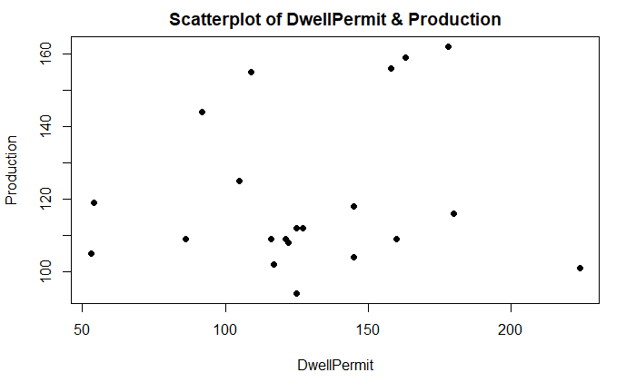

```r
# Scatterplot of DwellPermit & Production
plot(data$DwellPermit, data$Production, main="Scatterplot of DwellPermit & Production",
   xlab="DwellPermit", ylab="Production", pch=19)
```

**There seems be a very week positive association and one outlier near x=224 (Canada)**

## B) Solution:

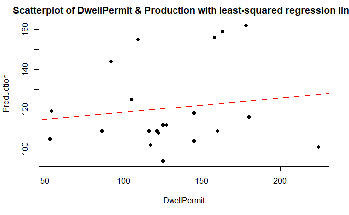

```r
# Scatterplot of DwellPermit & Production

plot(data$DwellPermit, data$Production, main="Scatterplot of DwellPermit & Production with least-squared regression line",
   xlab="DwellPermit", ylab="Production", pch=19)
# Add fit lines
abline(lm(Production~DwellPermit, data = data), col="red") # regression line (y~x)
```

### Using ggplot2

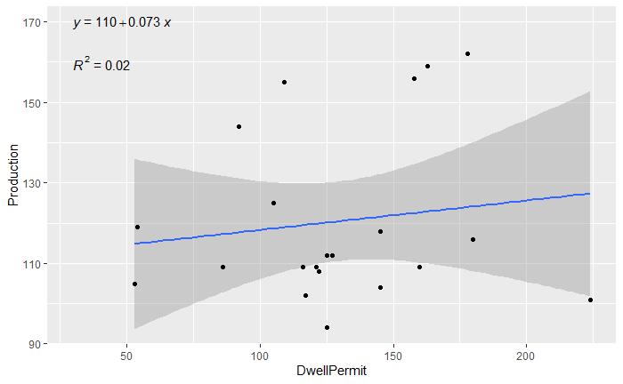

```r
#create plot with regression line, regression equation, and R-squared
ggplot(data=data, aes(x=DwellPermit, y=Production)) +
        geom_smooth(method="lm") +
        geom_point() +
        stat_regline_equation(label.x=30, label.y=170) +
        stat_cor(aes(label=..rr.label..), label.x=30, label.y=160)
```

## C) Solution:

```r
x = 160
sales = a*x + b
print(paste("Predicted value of Production for a country that has an index of 160 for dwelling permits is", sales))
```

```
[1] "Predicted value of Production for a country that has an index of 160 for dwelling permits is 122.662632802455"
```

## D) Solution:

```r
id = which(data$Country == "Netherlands" & data$DwellPermit==160)
```

```r
#List of residual for Netherlands (15th on the list)
print(paste("Residual for Netherlands is",resid(fit)[id]))
```

```
[1] "Residual for Netherlands is -13.6626328024547"
```

## E) Solution:

```r
cor(data$DwellPermit, data$Production)
```

```
[1] 0.1410671
```

```r
rsq <-  cor(data$DwellPermit, data$Production) ^ 2
rsq
```

```
[1] 0.01989992
```

*So 1.99% of the variance of Production can be explained by dwelling permits. In earlier exercise we observed a higher variance explanations between sales and dwelling permit which was due to higher association among the variables.*

# Problem 2.154

## A) Solution:

### Read xls file

```r
file_name = "ex02-152meis.xls"
data = read_xls(file_name)
```

### Preview tibble

```r
data
```

| Country | Sales | Production | DwellPermit |
| --- | --- | --- | --- |
| Australia | 137 | 109 | 116 |
| Belgium | 105 | 112 | 125 |
| Canada | 122 | 101 | 224 |
| Czech Republic | 134 | 162 | 178 |
| Denmark | 126 | 109 | 121 |
| Finland | 136 | 125 | 105 |
| France | 121 | 104 | 145 |
| Germany | 100 | 119 | 54 |
| Greece | 136 | 102 | 117 |
| Hungary | 140 | 155 | 109 |

[output cut: 11 more lines]

```r
summary(data)
```

```
   Country              Sales         Production     DwellPermit
 Length:21          Min.   : 99.0   Min.   : 94.0   Min.   : 53.0
 Class :character   1st Qu.:112.0   1st Qu.:108.0   1st Qu.:109.0
 Mode  :character   Median :126.0   Median :112.0   Median :125.0
                    Mean   :126.1   Mean   :120.4   Mean   :128.8
                    3rd Qu.:137.0   3rd Qu.:125.0   3rd Qu.:158.0
                    Max.   :161.0   Max.   :162.0   Max.   :224.0
```

```r
fit<- lm(data$Sales~ data$Production)
summary(fit)
```

```
Call:
lm(formula = data$Sales ~ data$Production)

Residuals:
    Min      1Q  Median      3Q     Max
-25.936 -12.327   1.213  12.018  35.178

Coefficients:
                Estimate Std. Error t value Pr(>|t|)
(Intercept)     112.2568    21.0657   5.329 3.83e-05 ***
data$Production   0.1150     0.1725   0.667    0.513
---
Signif. codes:  0 ‘***’ 0.001 ‘**’ 0.01 ‘*’ 0.05 ‘.’ 0.1 ‘ ’ 1

Residual standard error: 16.38 on 19 degrees of freedom
Multiple R-squared:  0.02285,   Adjusted R-squared:  -0.02858
F-statistic: 0.4443 on 1 and 19 DF,  p-value: 0.5131
```

```r
b = unname(fit$coefficients[1])
a = unname(fit$coefficients[2])
```

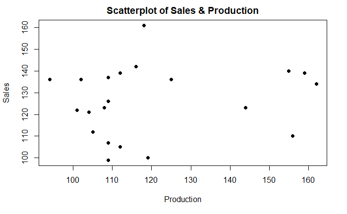

```r
# Scatterplot of Sales & Production
plot(data$Production, data$Sales, main="Scatterplot of Sales & Production",
   xlab="Production", ylab="Sales", pch=19)
```

**From the plot we get no clear relationship between the two variables.There is an outlier in the data and that is related to y=161 and x=118 (Luxembourg)**